RESEARCH ARTICLE

The anxiolytic effect of probiotics: A

systematic review and meta-analysis of the

clinical and preclinical literature

**Daniel J. Reis*****, Stephen S. Ilardi, Stephanie E. W. Punt**

Department of Psychology, University of Kansas, Lawrence, KS, United States of America

* daniel.reis@ku.edu

Abstract

**Background**

Probiotics have generated intensive research interest in recent years as a novel mode of

treatment for physical and mental illness. Nevertheless, the anxiolytic potential of probiotics

remains unclear. The present systematic review and meta-analysis aimed to evaluate the

clinical and preclinical (animal model) evidence regarding the effect of probiotic administra-

tion on anxiety.

**Methods**

The PubMed, PsycINFO, and Web of Science databases were reviewed for preclinical and

clinical studies that met the defined inclusion and exclusion criteria. The effects of probiotics

on anxiety-like behavior and symptoms of anxiety were analyzed by meta-analyses. Sepa-

rate subgroup analyses were conducted on diseased versus healthy animals, specific pre-

clinical probiotic species, and clinical versus healthy human samples.

**Results**

Data were extracted from 22 preclinical studies (743 animals) and 14 clinical studies (1527

individuals). Overall, probiotics reduced anxiety-like behavior in animals (Hedges’ g = -0.47,

95% CI -0.77 –-0.16, *p* = 0.004). Subgroup analyses revealed a significant reduction only

among diseased animals. Probiotic species-level analyses identified only *Lactobacillus* (*L*.)

*rhamnosus* as an anxiolytic species, but these analyses were broadly under-powered. Pro-

biotics did not significantly reduce symptoms of anxiety in humans (Hedges’ g = -0.12, 95%

CI -0.29–0.05, *p* = 0.151), and did not differentially affect clinical and healthy human

samples.

**Conclusions**

While preclinical (animal) studies suggest that probiotics may help reduce anxiety, such

findings have not yet translated to clinical research in humans, perhaps due to the dearth of

extant research with clinically anxious populations. Further investigation of probiotic

PLOS ONE | https://doi.org/10.1371/journal.pone.0199041

June 20, 2018

1 / 25

OPEN ACCESS

**Citation:** Reis DJ, Ilardi SS, Punt SEW (2018) The

anxiolytic effect of probiotics: A systematic review

and meta-analysis of the clinical and preclinical

literature. PLoS ONE 13(6): e0199041. https://doi.

org/10.1371/journal.pone.0199041

**Editor:** Jane Foster, McMaster University, CANADA

**Received:** January 8, 2018

**Accepted:** May 30, 2018

**Published:** June 20, 2018

**Copyright:** © 2018 Reis et al. This is an open

access article distributed under the terms of the

Creative Commons Attribution License, which

permits unrestricted use, distribution, and

reproduction in any medium, provided the original

author and source are credited.

**Data Availability Statement:** All relevant data are

within the paper and its Supporting Information

files.

**Funding:** The authors received no specific funding

for this work.

**Competing interests:** The authors have declared

that no competing interests exist.

treatment for clinically relevant anxiety is warranted, particularly with respect to the probiotic

species *L*. *rhamnosus*.

**Introduction**

Anxiety disorders are a class of psychological disturbances characterized by pervasive worry,

fear, and related behavioral impairments. Collectively, they are the most prevalent form of

mental illness [1]—affecting up to 30% of American adults at some point—and they impose a

large societal burden of functional disability and mortality [2]. Excessive anxiety is also associ-

ated with numerous negative health outcomes, such as increased risk of coronary heart disease

[3], impaired sleep [4], and alcohol and substance abuse [5]. Although there now exist several

established medication- and psychotherapy-based treatments for anxiety [6], many patients

still experience a poor treatment response [7, 8]. The widespread and debilitating nature of

anxiety, in tandem with the frequent inadequacy of existing treatments, points to the desirabil-

ity of exploring and developing novel approaches to treatment.

One particularly promising area of investigation involves manipulation of the intestinal

microbiota, the diverse collection of symbiotic microorganisms residing within the human gut

[9]. The microbiota communicates with the central nervous system via a collection of bidirec-

tional neural, metabolic, and immune pathways known as the microbiota-gut-brain axis [10].

Microbiota dysfunction—most commonly, the relative loss of beneficial gut microbes—is asso-

ciated with numerous types of physical and mental illness, ranging from irritable bowel syn-

drome to Alzheimer’s disease to depression [11]. The experience of anxiety is closely

interrelated with disordered gut function, to such an extent that commonly reported symp-

toms of anxiety often involve intestinal distress (e.g. upset stomach or nausea), and the severity

and duration of abdominal pain are associated with elevated anxiety [12]. Moreover, anxiety

frequently co-occurs with gastrointestinal disorders, such as irritable bowel syndrome, Crohn’s

disease, and ulcerative colitis [13, 14]—all of which are also linked with microbiota dysfunc-

tion [11]. Antibiotic use, which can profoundly reduce the gut’s bacterial diversity [15], has

also been found to increase the risk of developing an anxiety disorder later in life [16]. Finally,

gastrointestinal disturbance caused by pathogens can elicit anxiety. Intestinal infections in

humans are associated with increased risk of developing an anxiety disorder over the next two

years [17], and healthy mice infected with a foodborne pathogen have been shown to rapidly

display increased anxiety-like behavior [18], even in the absence of a detectable immune

response [19], suggesting that such microorganisms can directly interact with neural

pathways.

The most common way of addressing microbiota dysfunction and associated illness is

through the supplemental administration of *probiotics* (beneficial microorganisms). Recent

meta-analyses have found that probiotic intervention successfully reduces symptoms of both

irritable bowel syndrome [20] and ulcerative colitis [21]. Probiotics are even emerging as a rec-

ommended treatment for antibiotic-associated adverse events in children [22]. Additionally,

there is early evidence that probiotics may have psychotropic effects. Tillisch et al. [23], for

example, demonstrated that the consumption of probiotics altered emotional processing in the

brains of healthy women. Probiotics have also been shown to improve self-reported mood in

otherwise healthy adults experiencing negative affect [24]. And animal studies have found that

pretreatment with probiotics can protect against the neurological damage induced by both

acute and chronic stress [25, 26]. Given that these findings came from healthy humans (and

animals), they suggest that probiotics may have beneficial effects even in the absence of clinical

A systematic review and meta-analysis of the anxiolytic effect of probiotics

PLOS ONE | https://doi.org/10.1371/journal.pone.0199041

June 20, 2018

2 / 25

disease. This leaves open the possibility that probiotics may be useful for both disease preven-

tion and treatment via different underlying mechanisms.

Several recent reviews have summarized the extant literature regarding probiotics and anxi-

ety [27–29]. Probiotics appear to be capable of reducing anxiety-like behavior in animals [29],

although the impact of probiotics on anxiety in humans is less certain, with recent narrative

reviews arriving at differing conclusions [27–29]. Notably, the overall effect of probiotics on

anxiety has yet to be *quantified* for either preclinical or clinical research. Accordingly, the goal

of this study was to comprehensively summarize and quantify the existing evidence on the

relationship between probiotics and anxiety. To do so, systematic reviews and meta-analyses

were performed on both preclinical and clinical studies, respectively.

**Methods**

The preclinical and clinical reviews followed CAMARADES and PRISMA guidelines for con-

ducting systematic reviews and meta-analyses, respectively [30, 31]. The study was not prereg-

istered, and the protocol can be viewed at https://dx.doi.org/10.17504/protocols.io.nsadeae.

Inclusion and exclusion criteria were selected to maximize the acquisition of all possible stud-

ies that examined the effects of probiotic administration on anxiety-like behavior in rodents or

symptoms of anxiety in humans. Conference abstracts were omitted due to a lack of necessary

information.

**Preclinical criteria**

Preclinical studies were deemed eligible if they met the following inclusion criteria: 1) subjects

were either rats or mice; 2) a probiotic was experimentally administered; 3) anxiety-like behav-

ior was measured.

Studies that met one or more of the following criteria were excluded: 1) there was no

matched control group; 2) the probiotic was not living at time of administration (e.g. heat-

killed); 3) the probiotic was not administered directly to the tested subject (e.g. administered

to the mother of infant rodent); 4) means, standard deviations, and sample sizes were not avail-

able for the measured anxiety-like behavior; 5) the full text of the study was not available in

English.

**Clinical criteria**

Clinical studies were deemed eligible if they met the following inclusion criteria: 1) the study

described a randomized controlled trial; 2) at least one interventional arm administered a pro-

biotic; 3) an anxiety scale was used as a primary or secondary measure; 4) human participants

were included.

Studies that met one or more of the following criteria were excluded: 1) there was no

matched control group; 2) the probiotic was not living at time of administration (e.g. heat-

killed); 3) means, standard deviations, and sample sizes were not available for the anxiety mea-

surements; 4) the full text of the study was not available in English.

**Search strategy**

The systematic literature reviews were carried out using PubMed, PsycINFO, and Web of Sci-

ence databases, from the earliest record of the databases to November 2017. Search terms

included Bifidobacterium OR lactobacillus OR probiotic AND anxiety (see S1 Appendix for

the exemplar PubMed preclinical and clinical search strategies). Relevant references from the

identified publications were also included. The title and abstract for each search result were

A systematic review and meta-analysis of the anxiolytic effect of probiotics

PLOS ONE | https://doi.org/10.1371/journal.pone.0199041

June 20, 2018

3 / 25

then evaluated to identify potential studies, and, finally, full-texts were evaluated to determine

study inclusion. Screening and evaluation were performed in a standardized manner by two

independent reviewers (DR and SP). Disagreements during this process were resolved accord-

ing to the following process: 1) both reviewers independently reapplied the inclusion/exclusion

criteria to the study in question; 2) the two reviewers discussed the criteria until a consensus

was reached; 3) in cases for which a consensus could not be reached, it was planned for the

final decision to be made by an independent party (SI), although this was not necessary. The

flow charts of study selection can be viewed in Figs 1 and 2.

**Data collection**

Preclinical and clinical data was extracted from selected studies using custom forms and

included the following information based on CAMARADES and PRISMA guidelines [30, 31]:

1) study design characteristics, such as subject information (e.g. age, sex, health status, rodent

species) and type of intervention (e.g. probiotic composition, dosage, and duration); and 2)

outcome data (e.g. outcome measure, group sample sizes, mean value of effect, and group vari-

ance). Outcome data was included if it was derived from a measure of anxiety-like behavior or

anxiety symptoms—equivalency across measures was assumed for each meta-analysis. Data

for the final measurement of the interventional period was selected if the outcome was mea-

sured at multiple time periods. Potential study bias was evaluated using SYRCLE’s risk of bias

tool [32] for preclinical studies and the Cochrane Collaboration’s risk of bias tool [33] for clini-

cal studies. One reviewer (DR) extracted all included data, which was checked and confirmed

by a second reviewer (SP). Disagreements between reviewers during data extraction were

resolved by discussion.

One clinical study [34] reported only median values and interquartile range. In order to cal-

culate an SMD, the median value of the reported data was assumed to represent the mean and

the standard deviation was calculated by dividing the interquartile range by 1.35 [35].

When results were available only in graphical format, data was extracted using WebPlotDi-

gitizer graph digitization software [36]; graph digitization has been previously shown to be a

valid method for extracting study data [37], and WebPlotDigitizer has been recommend for

use in systematic reviews [38].

Finally, nine preclinical and 14 clinical authors were contacted and asked to provide further

information. Four preclinical and two clinical authors responded and provided additional

study data, which were included in the final study selection. Extracted data can be viewed in

Tables 1 and 2.

**Statistical analyses**

The preclinical and clinical meta-analyses were performed with R 3.2.5 software [39]. All anal-

yses were pre-specified unless otherwise stated. For each included study, the standardized

mean difference (SMD; also known as Hedges’ g) between the probiotic and matched control

groups was calculated for all continuous measures of anxiety-like behavior or anxiety symp-

toms. Confidence intervals were calculated for each SMD using a standard normal distribu-

tion. For both preclinical and clinical studies, sample size, probiotic duration, and probiotic

dose were assessed as moderating variables in individual meta-regressions. Separate subgroup

analyses were conducted on diseased (receiving experimental manipulations in addition to

probiotic or vehicle intervention) and naïve animals (receiving only probiotic or vehicle inter-

vention), as well as mouse and rat samples. Exploratory subgroup analyses were also per-

formed on studies that used matching individual or combined probiotic species, provided that

the probiotic was tested in at least three experimental groups. In humans, subgroup analyses

A systematic review and meta-analysis of the anxiolytic effect of probiotics

PLOS ONE | https://doi.org/10.1371/journal.pone.0199041

June 20, 2018

4 / 25

were conducted on clinical (individuals with a medical or psychological illness) and healthy

samples. Multiple subgroups within a single study (e.g. different rodent strains or experimental

conditions) were included as independent SMDs, provided that each treatment group had a

separate, matched control group. When multiple probiotic treatment groups were compared

against the same control group, the results from the different probiotic groups were combined,

and the SMD was calculated from the combined results [35].

If multiple measures of anxiety-like behavior or anxiety symptoms were reported in a single

study, a separate SMD was calculated for each outcome. To account for the dependency

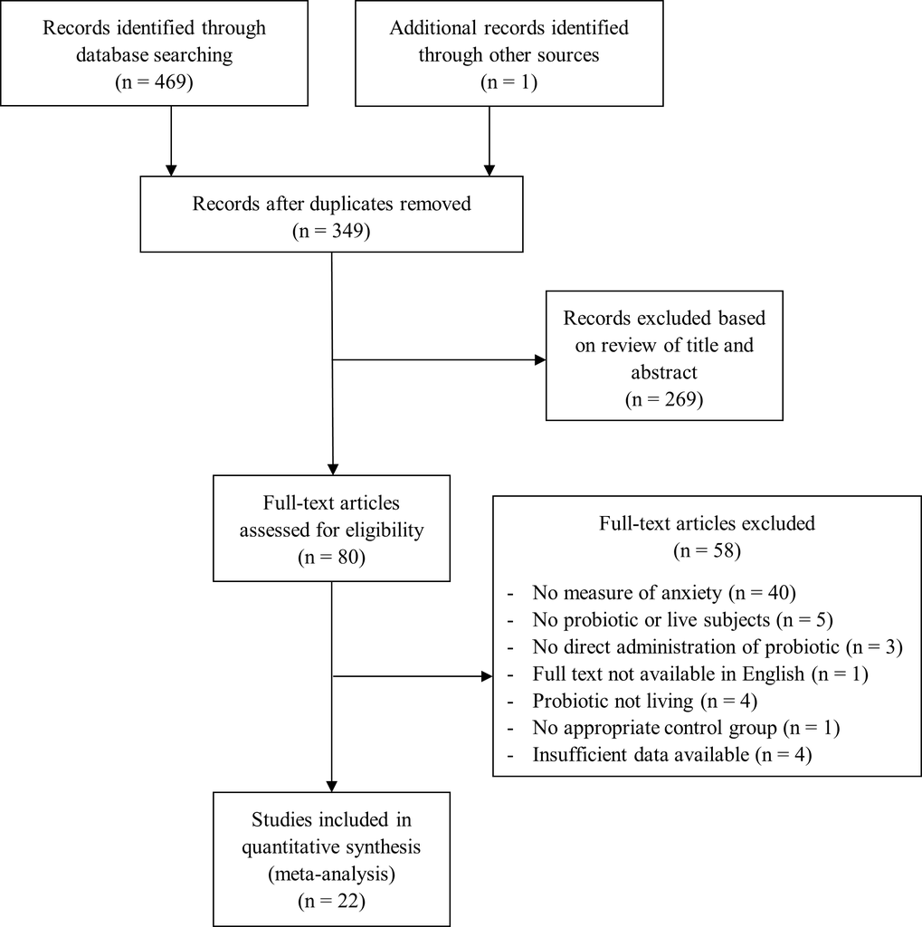

**Fig 1. Flow and selection of preclinical studies.**

https://doi.org/10.1371/journal.pone.0199041.g001

A systematic review and meta-analysis of the anxiolytic effect of probiotics

PLOS ONE | https://doi.org/10.1371/journal.pone.0199041

June 20, 2018

5 / 25

between SMDs measured in the same sample, robust variance estimation (RVE) meta-analyses

were used to estimate preclinical and clinical summary SMDs. RVE meta-analysis is a form of

random-effects meta-analysis that has been shown to address SMD dependency when the

covariances between outcomes measured in the same study are unknown [40]. In other words,

RVE allows for multiple outcomes from a single study to be included in a meta-analysis as sep-

arate SMDs; the weights are adjusted accordingly (i.e. the SMDs share a single study weight).

Precision (i.e. inverse variance) was used to weight SMDs.

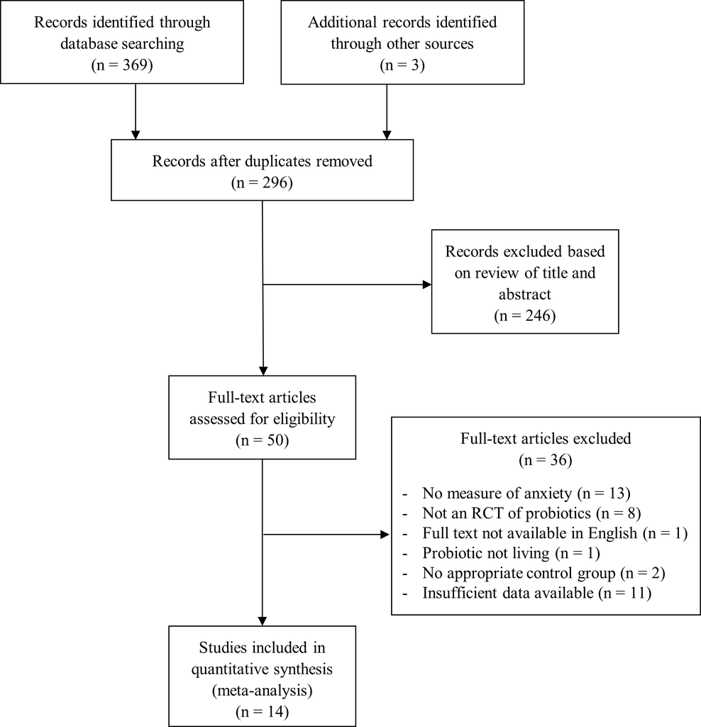

**Fig 2. Flow and selection of clinical studies.**

https://doi.org/10.1371/journal.pone.0199041.g002

A systematic review and meta-analysis of the anxiolytic effect of probiotics

PLOS ONE | https://doi.org/10.1371/journal.pone.0199041

June 20, 2018

6 / 25

**Table 1. Preclinical study characteristics.**

**Author, year**

**Subjects**

**No. of**

**subjects**

**Days of**

**intervention**

**Bacterial species and dosage (CFU)**

**Anxiety measure**

Agusti A, 2017

Group 1

Male C57BL-6 mice

20

98

*B*. *pseudocatenulatum* CECT 7765 (1 x 10<sup>9</sup>)

Open field test: $ time in center;

Light-dark test: $ latency

Agusti A, 2017

Group 2

Male C57BL-6 mice fed a

high-fat diet

20

98

*B*. *pseudocatenulatum* CECT 7765 (1 x 10<sup>9</sup>)

Open field test: $ time in center;

Light-dark test: $ latency

Barrera-

Bugueno C,

2017

Male Sprague-Dawley rats

18

14

*L*. *casei* 54-2-33 (1 x 10<sup>4</sup>CFU/mL of drinking

water)

Open field test: " time in center, "

entries into center; Elevated plus

maze: $ time in open arms, $

entries into open arms

Beilharz J,

2017 Group 1

Male Sprague-Dawley rats

30

36

*B*. *longum* DSM 24736, *B*. *infantis* DSM 24737,

*B*. *breve* DSM 24732, *L*. *acidophilus* DSM

24735, *L*. *paracasei* DSM 24733, *L*. *bulgaricus*

DSM 24734, *L*. *plantarum* DSM 24730,

*Streptococcus thermophilus subsp*. *thermophilus*

DSM 24731 (Low dose– 2.5 x 10<sup>9</sup>; High dose–

2.5 x 10<sup>10</sup>)

Elevated plus maze: $ time in open

arms

Beilharz J,

2017 Group 2

Male Sprague-Dawley rats fed

a cafeteria diet

29

36

*B*. *longum* DSM 24736, *B*. *infantis* DSM 24737,

*B*. *breve* DSM 24732, *L*. *acidophilus* DSM

24735, *L*. *paracasei* DSM 24733, *L*. *bulgaricus*

DSM 24734, *L*. *plantarum* DSM 24730,

*Streptococcus thermophilus subsp*. *thermophilus*

DSM 24731 (Low dose– 2.5 x 10<sup>9</sup>; High dose–

2.5 x 10<sup>10</sup>)

Elevated plus maze: $ time in open

arms

Bercik P, 2010

Male AKR mice infected with

*Trichuris muris*

42

30

*L*. *rhamnosus* NCC4007 *and B*. *longum*

NCC300*1* (1 x 10<sup>10</sup>)

Light-dark box test: # time in light

box, $ latency to re-enter light box;

Step-down test: # latency

Bercik P, 2011

Group 1

Male AKR mice exposed to

dextran sodium sulfate

23

14

*B*. *longum* (1 x 10<sup>10</sup>)

Step-down test: # latency

Bercik P, 2011

Group 2

Vagotomized male AKR mice

exposed to dextran sodium

sulfate

30

14

*B*. *longum* (1 x 10<sup>10</sup>)

Step-down test: $ latency

Bharwani A,

2017 Group 1

Male C57BL/6 mice

30

28

*L*. *rhamnosus* JB-1 (1.67 x 10<sup>9</sup>)

Light-dark box test: $ entries into

light zone

Bharwani A,

2017 Group 2

Male C57BL/6 mice exposed

to social defeat

31

28

*L*. *rhamnosus* JB-1 (1.67 x 10<sup>9</sup>)

Light-dark box test: # entries into

light zone

Bravo J, 2011

Male BALB/c mice

36

28

*L*. *rhamnosus* JB-1 (1 x 10<sup>9</sup>)

Elevated plus maze: # open arm

entries, $ time in open arms

Cowan C,

2016

Female Sprague-Dawley rats

16

13

*L*. *rhamnosus* R0011 and *L*. *helveticus* R0052 (1

x 10<sup>9</sup>CFU/mL of drinking water)

Elevated plus maze: $ open arm

entries, $ time in open arms, $

latency

Divyashri G,

2015

Male CFT-Swiss mice

24

28

*Enterococcus faecium* CFR 3003 (Low dose– 1

x 10<sup>4</sup>; High dose– 1 x 10<sup>8</sup>) or *L*. *rhamnosus* GG

MTCC 1408 (1 x 10<sup>8</sup>)

Elevated plus maze: # open arm

entries, # time in open arms; Open

field test: $ entries into center, $

time in center

Emge J, 2016

Group 1

Male and female C57BL/6

mice

10

15

*L*. *rhamnosus* R0011 and *L*. *helveticus* R0052 (2

x 10<sup>9</sup>)

Light-dark box test: $ time in light

box

Emge J, 2016

Group 2

Male and female C57BL/6

mice exposed to dextran

sodium sulfate

20

15

*L*. *rhamnosus* R0011 and *L*. *helveticus* R0052 (2

x 10<sup>9</sup>)

Light-dark box test: # time in light

box

Jang H, 2017

Male ICR mice exposed to

immobilization stress

24

3

*B*. *adolescentis* IM38 (Low dose– 2 x 10<sup>8</sup>;

Medium dose– 1 x 10<sup>9</sup>; High dose– 5 x 10<sup>9</sup>

CFU)

Elevated plus maze: # open arm

entries, # time in open arms

Liang S, 2015

Male specific-pathogen-free

Sprague-Dawley rats exposed

to chronic restraint stress

16

22

*L*. *helveticus* NS8 (1 x 10<sup>9</sup>CFU/mL of drinking

water)

Elevated plus maze: $ open arm

entries, # time in open arms; Open

field test: $ time in center

(*Continued*)

A systematic review and meta-analysis of the anxiolytic effect of probiotics

PLOS ONE | https://doi.org/10.1371/journal.pone.0199041

June 20, 2018

7 / 25

One clinical study included in the final analysis [41] utilized a cross-over experimental

design, but did not report the correlation between the interventional periods. A correlation of

0.5 was imputed to calculate the standard error of the SMD for the study. A sensitivity analysis,

using alternative correlational values to calculate the standard error, revealed that the choice of

correlational value did not impact the overall results of the clinical meta-analysis.

I<sup>2</sup>was used to evaluate between-study heterogeneity. Values of I<sup>2</sup>more than 25%, 50%, and

75% were selected to reflect low, moderate, and high heterogeneity, respectively, in accordance

**Table 1.** (Continued)

**Author, year**

**Subjects**

**No. of**

**subjects**

**Days of**

**intervention**

**Bacterial species and dosage (CFU)**

**Anxiety measure**

Liu W, 2016

Group 1

Male GF C57BL/BJNarl mice

20

16

*L*. *plantarum* PS128 (1 x 10<sup>9</sup>)

Elevated plus maze: # time in open

arms / time in closed arms ratio;

Open field test: $ time in center

Liu W, 2016

Group 2

Male C57BL/6J mice

12

16

*L*. *plantarum* PS128 (1 x 10<sup>9</sup>)

Elevated plus maze: # time in open

arms; Open field test: # time in

center

Liu Y, 2016

Group 1

Male C57BL/6J mice exposed

to early-life stress

20

28

*L*. *plantarum* PS128 (1 x 10<sup>9</sup>)

Elevated plus maze: $ time in open

arms; Open field test: $ time in

center

Liu Y, 2016

Group 2

Male C57BL/6J mice

18

28

*L*. *plantarum* PS128 (1 x 10<sup>9</sup>)

Elevated plus maze: # time in open

arms; Open field test: # time in

center

Luo J, 2014

Male specific-pathogen-free

Sprague-Dawley rats with

induced hyperammonemia

12

14

*L*. *helveticus* NS8 (1 x 10<sup>9</sup>)

Elevated plus maze: # open arm

entries, $ time in open arms

Mackos A,

2013 Group 1

Male outbred CD-1 mice

36

12

*L*. *reuteri* 23272 (1.5 x 10<sup>8</sup>)

Open field test: $ time spent in

center

Mackos A,

2013 Group 2

Male outbred CD-1 mice

exposed to prolonged-

restraint

18

12

*L*. *reuteri* 23272 (1.5 x 10<sup>8</sup>)

Open field test: $ time spent in

center

Matthews D,

2013

Male specific-pathogen-free

BALB/c mice

18

Administered

several times over

7 weeks

*Mycobacterium vaccae* 15,483 (4.5 x 10<sup>5</sup>)

Anxiety-like behaviors during maze

task: $ immobilization, $

grooming, $ latency to start

McKernan D,

2010 Group 1

Male Sprague-Dawley rats

40

14

*L*. *salivarius* UCC118 (1 x 10<sup>9</sup>); or *B*. *infantis*

35624 (1 x 10<sup>9</sup>); or *B*. *breve* UCC2003 (1 x 10<sup>9</sup>)

Open field test: $ time in center

McKernan D,

2010 Group 2

Male Wistar-Kyoto rats

40

14

*L*. *salivarius* UCC118 (1 x 10<sup>9</sup>); or *B*. *infantis*

35624 (1 x 10<sup>9</sup>); or *B*. *breve* UCC2003 (1 x 10<sup>9</sup>)

Open field test: $ time in center

Moya-Perez

A, 2017 Group

1

Male C57Bl/6J mice

18

20

*B*. *pseudocatenulatum* CECT 7765 (1 x 10<sup>8</sup>

CFU)

Elevated plus maze: $ time in open

arms

Moya-Perez

A, 2017 Group

2

Male C57Bl/6J mice exposed

to early-life stress

18

20

*B*. *pseudocatenulatum* CECT 7765 (1 x 10<sup>8</sup>

CFU)

Elevated plus maze: # time in open

arms; Open field test: $ entries

into center

Smith C, 2014

Group 1

Male and female wild-type

*Rag1*<sup>*-/-*</sup>mice

12

28

*L*. *rhamnosus* R0011 and *L*. *helveticus* R0052 (6

x 10<sup>9</sup>)

Light-dark box test: # time in light

box

Smith C, 2014

Group 2

Male and female wild-type

*Rag1*<sup>*-/-*</sup>mice exposed to water

avoidance stress

10

28

*L*. *rhamnosus* R0011 and *L*. *helveticus* R0052 (6

x 10<sup>9</sup>)

Light-dark box test: # time in light

box

Vanhaecke T,

2017

Sprague-Dawley rats

12

15

*L*. *fermentum* CECT 5716 (1 x 10<sup>9</sup>CFU/100g

body weight)

Elevated plus maze: $ open arm

entries

Wang T, 2015

Male Sprague-Dawley rats

exposed to an antibiotic

20

30

*L*. *fermentum* NS9 (1 x 10<sup>9</sup>CFU/mL of

drinking water)

Elevated plus maze: # open arm

entries

# and " represent a statistically significant decrease or increase (respectively) in anxiety-like behavior in at least one probiotic treatment group, while $ represents a

nonsignificant or unclear change.

https://doi.org/10.1371/journal.pone.0199041.t001

A systematic review and meta-analysis of the anxiolytic effect of probiotics

PLOS ONE | https://doi.org/10.1371/journal.pone.0199041

June 20, 2018

8 / 25

with guidelines described by Higgins et al. [42]. Potential publication bias was assessed via fun-

nel plot and Egger test [43].

**Results**

**Preclinical meta-analysis**

**Study selection and characteristics.**

Twenty-two studies [44–65] with 33 independent

experimental groups and 743 rodent subjects were included in the preclinical meta-analysis

(Fig 1 and Table 1). Eight studies used rats as experimental subjects, while the other 14 used

mice. All but four studies [51, 53, 63, 64] reported using only male rodents. Fifteen of the 33

experimental groups modeled a form of disease and were exposed to additional manipulation,

such as social defeat [49], early-life stress [57], or induced chronic colitis [47]. Thirteen studies

**Table 2. Clinical study characteristics.**

**Author, year**

**Subjects (age)**

**No. of**

**subjects**

**Intervention**

**(days)**

**Bacterial species and dosage (CFU)**

**Anxiety scale**

Kato-Kataoka A,

2016

Healthy 4<sup>th</sup>-grade medical

students (average age ~23)

47

Milk (56)

*L*. *casei Shirota* YIT 9029 (1 x 10<sup>11</sup>)

$ STAI-state

Kelly J, 2017

Healthy adults (average age

24.6, 20–33 range)

29 (crossover

design)

Capsule (28)

*L*. *rhamnosus* JB-1 (1 x 10<sup>9</sup>)

$ STAI-state, $ STAI-

trait, and $ BAI

Lorenzo-Zuniga

V, 2014

Adults with IBS with

diarrhea (20–70 range)

71

Capsule (42)

*L*. *plantarum* CECT 7484, *L*. *plantarum* CECT 7485,

and *Pediococcus acidilactici* CECT 7483 (Low dose–

3–6 x 10<sup>9</sup>; High dose– 1–3 x 10<sup>10</sup>)

# Visceral Sensitivity

Index

Lyra A, 2016

Adults with IBS (18–65

range)

332

Capsule (84)

*L*. *acidophilus* NCFM (Low dose– 1 x 10<sup>9</sup>; High dose– 1

x 10<sup>10</sup>)

$ HADS-anxiety

subscale

Marcos A, 2004

Healthy students (18–23

range)

136

Milk (42)

*L*. *delbrueckii* subsp. *bulgaricus* (2 x 10<sup>9</sup>), *Streptococcus*

*salivarius* subsp. *thermophilus* (2 x 10<sup>10</sup>), *L*. *casei*

DN114001 (2 x 10<sup>10</sup>)

$ STAI-state and $

STAI-trait

Messaoudi M,

2011

Healthy adults (average age

~43)

55

Powder (30)

*L*. *helveticus* R0052 *and B*. *longum* R0175 (3 x 10<sup>9</sup>)

$ HADS-anxiety and

$ HSCL-90 anxiety

Pinto-Sanchez

M, 2017

Adults with IBS (median age

~43)

38

Powder (42)

*B*. *longum* NCC3001 (1 x 10<sup>10</sup>)

$ HADS-anxiety, $

STAI-state, and $

STAI-trait

Romijn A, 2017

Adults (age 16+) with at least

moderate low mood (average

age ~35)

79

Powder (56)

*L*. *helveticus* R0052 *and B*. *longum* R0175 (2 x 10<sup>10</sup>)

$ DASS-42 anxiety

subscale

Simren M, 2010

Adults with IBS (average age

~43)

67

Yogurt (56)

*L*. *paracasei* subsp. *paracasei* F19, *L*. *acidophilus* La5,

and *B*. *lactis* Bb12 (2 x 10<sup>10</sup>)

$ HADS-anxiety

subscale

Slykerman R,

2017

Pregnant women (average

age ~34)

379

Capsule (Up to

~1 year)

*L*. *rhamnosus* HN001 (6 x 10<sup>9</sup>)

# STAI-6 item version

Steenbergen L,

2015

Healthy adults (average age

~20)

40

Powder (28)

*B*. *bifidum* W23, *B*. *lactis* W52, *L*. *acidophilus* W37, *L*.

*brevis* W63, *L*. *casei* W56, *L*. *salivarius* W24,

*Lactococcus lactis* W19 and W58 (5 x 10<sup>9</sup>)

$ BAI

Takada M, 2016

Healthy 4<sup>th</sup>-grade medical

students (average age ~23)

140

Milk (56)

*L*. *casei Shirota* YIT 9029 (1 x 10<sup>11</sup>)

$ STAI-state

Takada M, 2017

Healthy 4<sup>th</sup>-grade medical

students (average age ~23)

94

Milk (77)

*L*. *casei Shirota* YIT 9029 (1 x 10<sup>11</sup>)

$ STAI-state

Yang H, 2016

Patients with cancer (average

age ~58)

20

Capsule (14)

*Clostridium butyricum* (CFU not reported– 420 mg per

capsule)

# HAMA

STAI = State-Trait Anxiety Inventory; BAI = Beck Anxiety Inventory; HADS = Hospital Anxiety and Depression Scale; HSCL-90 = Hopkins Symptom Checklist-90;

DASS = Depression Anxiety Stress Scales; HAMA = Hamilton Anxiety Rating Scale.

# and " represent a statistically significant decrease or increase (respectively) in anxiety-like behavior in at least one probiotic treatment group, while $ represents a

nonsignificant or unclear change.

https://doi.org/10.1371/journal.pone.0199041.t002

A systematic review and meta-analysis of the anxiolytic effect of probiotics

PLOS ONE | https://doi.org/10.1371/journal.pone.0199041

June 20, 2018

9 / 25

assessed anxiety-like behavior using an elevated plus maze, five studies used a light-dark

box test, two studies used a step-down test, nine studies used an open field test, and one study

observed behaviors related to anxiety during a maze task (eight studies employed multiple par-

genera were used as probiotics.

**Bias assessment.**

Table 3 shows the assessment of the risk of bias for the included studies.

No study provided sufficient detail regarding performance bias or detection bias, and only one

study provided detail regarding selection bias. This lack of reporting makes it difficult, if not

impossible, to accurately determine risk of bias. More detail was provided regarding the risk of

attrition bias, reporting bias, and other bias. Four studies had a high risk of reporting bias [49,

57, 60, 62], and three studies had a high risk of other bias [45, 53, 59]. A separate sensitivity

analysis revealed that removal of these studies did not substantively impact the results. Overall,

the risk of bias for each included study is unclear.

**Probiotic efficacy.**

Combining standardized mean differences (SMDs) for the 33 included

experimental groups revealed a pooled SMD of -0.47 (95% CI -0.77 –-0.16, *p* = 0.004; Fig 3).

Probiotic administration, compared to placebo, was shown to significantly reduce anxiety-like

behavior in rodents. Neither sample size (β = 0.01, 95% CI: -0.02–0.04, *p* = 0.432), probiotic

duration (β = 0.01, 95% CI: -0.02–0.04, *p* = 0.372), nor probiotic dose (β = -0.006, 95% CI:

-0.12–0.11, *p* = 0.906) provided a significant moderating influence.

Subgroup analyses revealed that probiotic administration significantly reduced anxiety-like

behavior in diseased (SMD = -0.81, 95% CI: -1.27 - -0.35, p = 0.002), but not in naïve animals

**Table 3. Preclinical risk of bias assessment.**

**Study**

**Baseline characteristics**

**Incomplete outcome data**

**Selective reporting**

**Other bias**

Agusti et al. 2017

Unclear

Low

Low

Low

Barrera-Bugueno et al. 2017

Unclear

Low

Low

High

Beilharz et al. 2017

Unclear

Low

Low

Low

Bercik et al. 2010

Unclear

Low

Low

Unclear

Bercik et al. 2011

Unclear

Unclear

Low

Unclear

Bharwani et al. 2017

Unclear

Unclear

High

Unclear

Bravo et al. 2011

Unclear

Unclear

Low

Low

Cowan et al. 2016

Low

Unclear

Low

Low

Divyashri et al. 2015

Unclear

Unclear

Low

Unclear

Emge et al. 2016

Unclear

Unclear

Low

High

Jang et al. 2017

Unclear

Low

Low

Low

Liang et al. 2015

Unclear

Low

Low

Low

Liu, W et al. 2016

Unclear

Low

Low

Low

Liu, Y et al. 2016

Unclear

Unclear

High

Low

Luo et al. 2014

Unclear

Low

Low

Low

Mackos et al. 2013

Unclear

Low

Low

High

Matthews et al. 2013

Unclear

Low

High

Low

McKernan et al. 2010

Unclear

Low

Low

Unclear

Moya-Perez et al. 2017

Unclear

Low

High

Low

Smith et al. 2014

Unclear

Unclear

Low

Unclear

Vanhaecke et al. 2017

Unclear

Unclear

Low

Unclear

Wang et al. 2015

Unclear

Low

Low

Unclear

Risk of bias relating to Sequence generation, Allocation concealment, Random housing, Blinding (intervention), Random outcome assessment, and Blinding

(assessment) was Unclear for all included studies, and as such these domains have been omitted from the table

https://doi.org/10.1371/journal.pone.0199041.t003

A systematic review and meta-analysis of the anxiolytic effect of probiotics

PLOS ONE | https://doi.org/10.1371/journal.pone.0199041

June 20, 2018

10 / 25

(SMD = -0.16, 95% CI: -0.58–0.26, *p* = 0.433). Furthermore, probiotics significantly reduced

anxiety-like behavior in mice (SMD = -0.58, 95% CI: -0.90 –-0.26, *p* = 0.001), but not rats

(SMD = -0.17, 95% CI: -1.07–0.73, *p* = 0.678).

Four probiotics were selected for additional subgroup analyses based on their utilization in

multiple trials: *Lactobacillus* (*L*.) *rhamnosus*, *Bifidobacterium* (*B*.) *pseudocatenulatum*, *L*. *plan-*

*tarum* (four experimental groups each), and combined *L*. *rhamnosus* and *L*. *helveticus* (five

experimental groups). Only *L*. *rhamnosus* was shown to significantly reduce anxiety-like

behavior (SMD = -0.77, 95% CI: -1.40 –-0.13, *p* = 0.018). Anxiety-like behavior was not

affected by *B*. *pseudocatenulatum* (SMD = -0.24, 95% CI: -0.76–0.28, *p* = 0.368), *L*. *plantarum*

(SMD = -0.50, 95% CI: -1.37–0.38, *p* = 0.264), or combined *L*. *rhamnosus* and *L*. *helveticus*

(SMD = -0.61, 95% CI: -1.54–0.32, *p* = 0.201).

**Publication bias and heterogeneity.**

Visual inspection of a funnel plot (Fig 4) and the use

of an Egger test (*t* = -0.15, *df* = 55, *p* = 0.880) did not suggest the presence of publication bias,

although several SMDs fell outside of the expected area of the funnel plot. Factors other than

publication bias can contribute to funnel plot asymmetry, including heterogeneity and other

forms of bias [66]. There was moderate heterogeneity across the 33 experimental groups (I<sup>2</sup>=

70.5%), indicating that 70.5% of the variation between study outcomes is attributable to incon-

sistency between the studies. Funnel plot asymmetry and heterogeneity are well-documented

problems present in meta-analyses of animal research [67]. Factors such as subject species/

strain, sample size, and additional experimental conditions can contribute to these issues,

although inclusion of study characteristics as moderating variables and subgroup analyses did

not reduce heterogeneity in the present analysis.

**Clinical meta-analysis**

**Study selection and characteristics.**

Fourteen studies [34, 41, 68–79], consisting of 1527

individuals, were included in the clinical meta-analysis (Fig 2 and Table 2). Eight studies

assessed the effect of probiotic administration on healthy samples, while six studies did so with

clinical samples. Of the six studies that used clinical participants, four studies investigated par-

ticipants with irritable bowel syndrome [69, 70, 72, 74], one study investigated participants

with at least moderate mood disturbance [73], and one study investigated participants with

cancer [79]. Two studies divided their participants receiving probiotic into low and high dose

groups [69, 70]. One study used a crossover randomized controlled trial design [41], while the

other 13 studies used a parallel design. Species from the *Lactobacillus*, *Bifidobacterium*, *Pedio-*

*coccus*, *Streptococcus*, and *Clostridium* genera were used as probiotics.

**Bias assessment.**

The assessment for the included studies’ risk of bias can be viewed in

Table 4. All 14 studies had a low risk of attrition bias, and most studies had a low risk of both

reporting and other bias. Less than half of the studies included details regarding allocation

concealment. Overall, the risk of bias for each included study ranged from low to unclear.

**Probiotic efficacy.**

Combining standardized mean differences (SMDs) for the 14 included

studies revealed a pooled SMD of -0.12 (95% CI: -0.29–0.05, *p* = 0.151; Fig 5), indicating that

probiotic administration did not result in a significant reduction of anxiety. Neither sample

size (β = 0.00, 95% CI: 0.00–0.00, *p* = 0.746), probiotic duration (β = 0.00, 95% CI: -0.01–0.01,

*p* = 0.915), nor probiotic dose (β = 0.00, 95% CI: -0.01–0.01, *p* = 0.433) provided a moderating

influence. Additionally, subgroup analyses revealed that probiotic administration did not

result in a significant reduction of anxiety in healthy (SMD = -0.10, 95% CI: -0.33–0.13,

*p* = 0.283) or clinical participants (SMD = -0.33, 95% CI: -1.08–0.43, *p* = 0.312).

**Publication bias and heterogeneity.**

Visual inspection of Fig 6 demonstrated symmetry,

apart from one study [79], while the use of an Egger test similarly did not suggest the presence

A systematic review and meta-analysis of the anxiolytic effect of probiotics

PLOS ONE | https://doi.org/10.1371/journal.pone.0199041

June 20, 2018

11 / 25

of publication bias (*t* = 1.52, *df* = 18, *p* = 0.146). There was also moderate heterogeneity across

the 14 included studies (I<sup>2</sup>= 61.8%). Removal of the study by Yang et al. [79] resulted in low

heterogeneity (I<sup>2</sup>= 21.7%); however, the results of the meta-analysis remained unchanged.

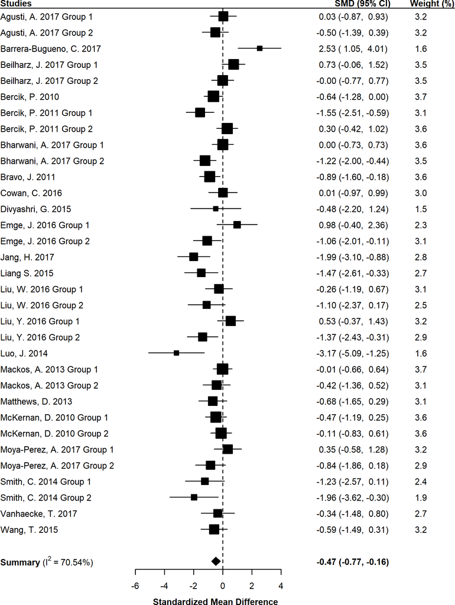

**Fig 3. Forest plot of preclinical studies investigating the effect of probiotics on anxiety-like behavior.** SMD = Standardized

mean difference; CI = Confidence interval. An aggregate SMD is displayed for each experimental group. Measure-specific SMDs

can be viewed in S1 Fig.

https://doi.org/10.1371/journal.pone.0199041.g003

A systematic review and meta-analysis of the anxiolytic effect of probiotics

PLOS ONE | https://doi.org/10.1371/journal.pone.0199041

June 20, 2018

12 / 25

**Discussion**

The present systematic review and meta-analysis of 22 preclinical studies (743 animals)

revealed a significant overall effect of probiotic administration in reducing anxiety-like behav-

ior in rodents. The observed pooled standardized mean difference (SMD) of -0.47 reflects a

medium-sized effect of probiotic interventions in comparison with non-probiotic controls. At

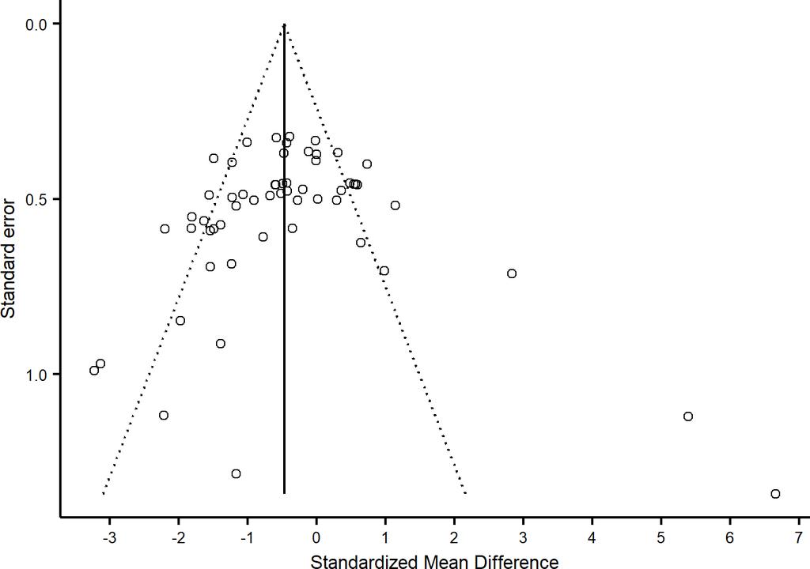

**Fig 4. Funnel plot of preclinical standardized mean differences.**

https://doi.org/10.1371/journal.pone.0199041.g004

**Table 4. Clinical risk of bias assessment.**

**Study**

**Random sequence**

**generation**

**Allocation**

**concealment**

**Blinding of**

**participants**

**Blinding of**

**assessor**

**Incomplete outcome**

**data**

**Selective**

**reporting**

**Other**

**bias**

Kato-Kataoka et al.

2016

Unclear

Unclear

Unclear

Unclear

Low

Low

Low

Kelly et al. 2017

Unclear

Unclear

Unclear

Unclear

Low

Unclear

Unclear

Lorenzo-Zuniga et al.

2014

Low

Unclear

Low

Low

Low

Low

Low

Lyra et al. 2016

Low

Unclear

Low

Low

Low

Low

Low

Marcos et al. 2004

Unclear

Unclear

Unclear

Unclear

Low

Low

Unclear

Messaoudi et al. 2011

Low

Low

Low

Low

Low

Unclear

Low

Pinto-Sanchez et al.

Low

Low

Low

Low

Low

Low

Low

Romijn et al. 2017

Low

Low

Low

Low

Low

Low

Low

Simren et al. 2010

Unclear

Low

Low

Low

Low

Low

Low

Unclear

Unclear

Low

Low

Low

Low

Low

Steenbergen et al.

2015

Unclear

Unclear

Low

Low

Low

Low

Low

Takada et al. 2016

Low

Unclear

Unclear

Unclear

Low

Low

Low

Takada et al. 2017

Low

Low

Unclear

Unclear

Low

Low

Low

Yang et al. 2016

Unclear

Unclear

Unclear

Unclear

Low

Low

Unclear

https://doi.org/10.1371/journal.pone.0199041.t004

A systematic review and meta-analysis of the anxiolytic effect of probiotics

PLOS ONE | https://doi.org/10.1371/journal.pone.0199041

June 20, 2018

13 / 25

In contrast, only 3 of the 14 included clinical studies (encompassing 1527 individuals)

found that probiotics significantly reduced symptoms of anxiety. Notably, probiotics also

yielded no overall anxiolytic effects in the present meta-analysis. Subgroup analyses likewise

observed no significant probiotic effects among either healthy or diseased human participants.

These findings stand in stark contrast with the conclusions of two recent qualitative reviews,

both of which proposed that probiotics may have anxiolytic properties [27, 29]. However,

unlike such reviews, the present study utilized meta-analytic techniques to quantitatively eval-

uate the magnitude of probiotic effects on anxiety, as well as the degree to which the reported

effects of different studies varied. This approach also enabled the inclusion of multiple mea-

sures of anxiety from relevant studies in a single summary analysis. As such, the reported

results provide the only comprehensive review to date of the relevant research.

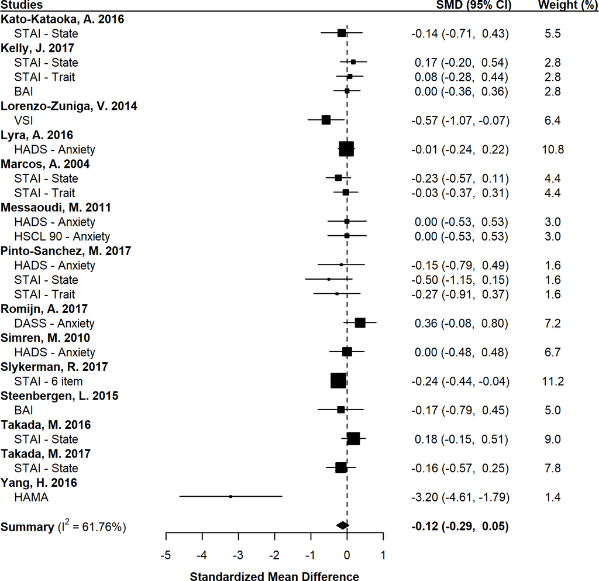

**Fig 5. Forest plot of clinical studies investigating the effect of probiotics on anxiety-like behavior.** SMD = Standardized

mean difference; CI = Confidence interval; STAI = State-Trait Anxiety Inventory; BAI = Beck Anxiety Inventory;

VSI = Visceral Sensitivity Index; HADS = Hospital Anxiety and Depression Scale; HSCL-90 = Hopkins Symptom Checklist-

90; DASS = Depression Anxiety Stress Scales; HAM-A = Hamilton Anxiety Rating Scale.

https://doi.org/10.1371/journal.pone.0199041.g005

A systematic review and meta-analysis of the anxiolytic effect of probiotics

PLOS ONE | https://doi.org/10.1371/journal.pone.0199041

June 20, 2018

14 / 25

In perhaps this study’s most important set of subgroup analyses, probiotics were found to

successfully reduce anxiety-like behavior in diseased, but not in healthy, rodents. Although the

utilized disease models varied considerably across studies—ranging from rodents with induced

intestinal inflammation [47, 48, 53] to those exposed to stressful conditions [49, 54, 59] to

those fed an unhealthy diet [44, 46]—they all reflected the presence of a pathological state that

might be associated with elevated stress or anxious arousal. It is possible, therefore, that the

anxiolytic effects of probiotics only occur above a baseline threshold level of heightened anx-

ious arousal. If so, this phenomenon could help explain the absence of an observed therapeutic

(anti-anxiety) effect of probiotic supplementation in our meta-analysis of human trials, inas-

much as none of the included studies specifically recruited participants on the basis of anxiety-

related symptomatology. Indeed, the majority (8) of included studies simply assessed the effect

of probiotics on self-reported anxiety levels among healthy, non-clinical participants. Another

four studies recruited patients with irritable bowel syndrome (IBS) [69, 70, 72, 74], and

although such patients may sometimes experience elevated anxiety [13], it is not a defining fea-

ture of the disorder. The remaining two clinical studies likewise selected participants based on

criteria other than anxiety severity [73, 79]. Simply put: the general absence of clinically salient

anxiety among human participants in the extant probiotic literature may have obscured any

potential anxiolytic effects. Accordingly, it will be useful and informative for future investiga-

tions in this area to explicitly target participants characterized by clinically significant anxiety.

The discrepancy between preclinical and clinical studies may also be due to differences in

the way that anxiety was evaluated across these groups. Whereas anxiety in humans was

assessed entirely through self-report measures, anxiety in rodents was assessed through behav-

ioral observations. There is evidence that, during the treatment of emotion-based disorders

such as depression or anxiety, cognitive and behavioral processes improve prior to any subjec-

tive awareness of recovery, which may take weeks to be fully realized [80]. It is possible that

self-report questionnaires of anxiety are not sensitive enough to detect probiotic-induced

anxiolysis, at least under typically studied treatment durations. Only half of the included

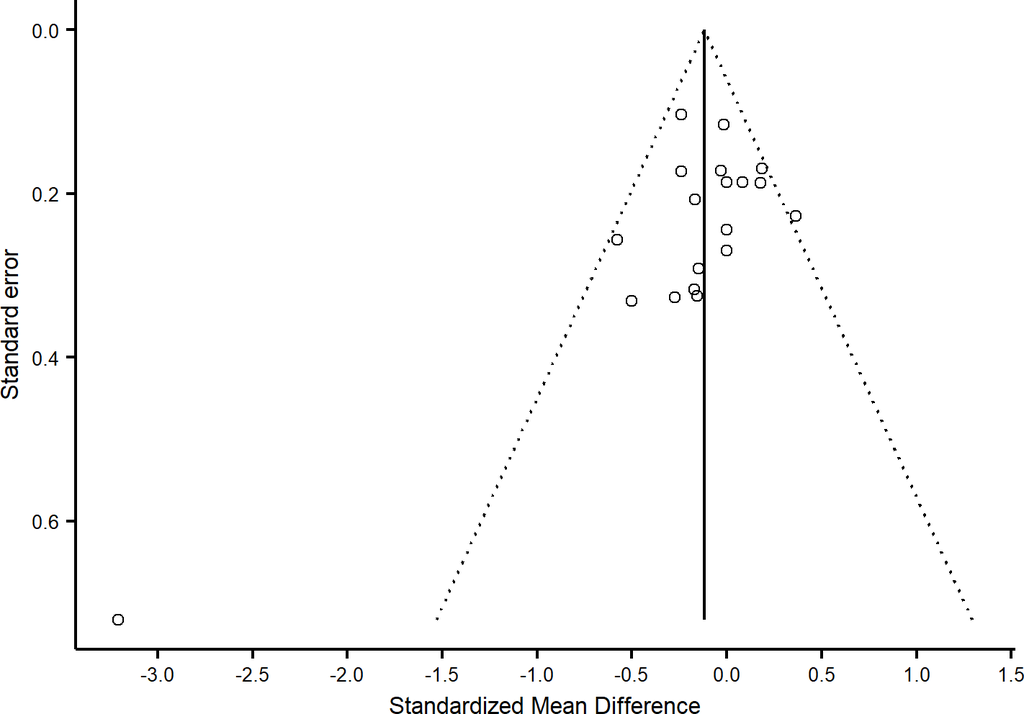

**Fig 6. Funnel plot of clinical standardized mean differences.**

clinical studies administered probiotics for at least eight weeks, which is often used as an upper

cutoff when determining response to pharmacological treatments such as antidepressants. In

addition to longer treatment durations, alternative forms of assessment, such as functional

imaging techniques, may be needed in clinical studies to accurately measure the anxiolytic

impact of probiotics. Encouragingly, at least one study to date has demonstrated that probiot-

ics can alter emotional processing as measured by functional imaging [23].

In terms of the specific probiotic supplement regimens employed, the 14 relevant human

trials to date were characterized by such a high level of between-study heterogeneity that more

fine-grained analyses of individual probiotic species were precluded. However, the preclinical

studies were subjected to further subgroup analyses on the basis of four species of probiotic

that were each utilized in several studies. Among these four candidate species, only *Lactobacil-*

*lus* (*L*.) *rhamnosus* was found to significantly reduce anxiety-like behavior, with a rather large

standardized mean difference (SMD) of -0.77 across the relevant trials [49, 50, 52]. Each of the

*L*. *rhamnosus* studies used an administration duration of 28 days, with specific strains consist-

ing of *L*. *rhamnosus* JB-1 [49, 50] and *L*. *rhamnosus* GG MTCC 1408 [52]. Notably, *L*. *rhamno-*

*sus* was also the probiotic species used in one of the only studies to observe a significant

anxiolytic effect in humans [75]. This particular species has been widely investigated, and has

been shown to attenuate the symptoms of various gastrointestinal and allergic diseases [81].

Based on our results, it appears that *L*. *rhamnosus* may also have psychotropic properties, and

should be further and more extensively investigated for its anxiolytic potential.

Other probiotic species that were shown to significantly reduce anxiety-like behavior in

individual rodent studies include *L*. *helveticus* [55, 58], *Bifidobacterium* (*B*.) *longum* [47], *B*.

*adolescentis* [54], and combined *L*. *rhamnosus* and *B*. *longum* [48]. Conversely, one species of

probiotic was shown to *increase* anxiety-like behavior in rodents: *L*. *casei* [45]. While *Lactoba-*

*cillus* and *Bifidobacterium* species of bacteria are the most commonly investigated probiotics

[82], the different species are not identical, and even strains within the same species can have

unique effects on the body [83]. Because of this, candidate probiotics require extensive study

and characterization prior to clinical application.

Notably, the dose-response curve of probiotics also remains almost completely uninvesti-

gated when it comes to their potential psychoactive effects. In fact, the weight-adjusted probi-

otic dosages (colony-forming units per gram of body weight) used in the rodent trials

reviewed herein were typically *hundreds of times larger* than the corresponding dosages used in

the human trials. And this fact raises the possibility that the significant anxiolytic effect of sup-

plementation in the rodent meta-analysis and the null effect in the human meta-analysis both

reflect—at least in part—the much higher dosing schedule utilized with the rodents. The same

consideration could also help explain the more robust anxiolytic effect observed among mice

versus rats, as the mice typically received higher weight-adjusted probiotic doses by virtue of

being about 10 times smaller than rats, on average. By extension, it is conceivable that future

investigators could discover the most effectively anxiolytic probiotic dosages in humans to be

dozens—or perhaps even hundreds—of times higher than those employed to date.

It is possible that probiotics reduce anxiety-like behavior by influencing the immune sys-

tem, which is a primary component of the microbiota-gut-brain axis [10]. Many of the

included preclinical studies found the anxiolytic effects of probiotics to be accompanied by

beneficial alterations in immune functioning [49, 52, 54, 55, 57, 58]. And the microbiota con-

tinuously stimulates a complex and dynamic immune response by interacting with the intesti-

nal barrier [84]. Germ-free mice without a microbiota have an impaired immune response

[85], and induced dysbiosis has been linked with inflammatory bowel disease [86]. As such,

probiotics may improve mental health by restoring microbiota-mediated immune activation

to an adaptive level. Another possibility is that the anxiolytic effects observed herein were due

to an alteration of activity in the vagus nerve, also a major connection between the microbiota

and the brain [10]. In fact, two of the reviewed preclinical studies found that inhibition of the

vagus nerve—a major pathway between the microbiota and the central nervous system [87]—

prevented probiotic-induced reductions of anxiety-like behavior [47, 50].

It should be emphasized that none of the analyzed preclinical studies provided sufficient

detail regarding risk of selection, performance, or detection biases, making it so that the overall

risk of bias for each preclinical study was unclear. Most clinical studies were similarly rated as

having an unclear risk of bias, especially within the domains of randomization, allocation con-

cealment, and blinding. As such, there is some concern that bias present in the included stud-

ies may be affecting the observed results. Failure to account for potential biases has been

shown to influence study outcomes and can lead to overestimation of observed effects [88, 89].

For example, animal studies that do not employ randomization procedures have been found to

have significantly higher standardized mean differences than those that do [90]. Furthermore,

an incomplete description of study methods can complicate replication efforts and evaluations

of study reliability. Poor reporting of bias risk criteria is a particular issue within the broader

preclinical literature, and certainly not isolated to probiotic research [91]. The use of appropri-

ate randomization, allocation concealment, and blinding procedures, as well as proper report-

ing thereof, will greatly aid preclinical and clinical probiotic development research.

Two of the 14 included clinical studies found that probiotic administration resulted in a sig-

nificant improvement of anxiety, compared to placebo, without contributing substantially to

statistical heterogeneity [69, 75]. Notably, Slykerman et al. [75] administered probiotics to

pregnant women for up to one year, the longest duration of any study included in this analysis.

Because the composition of the microbiota is relatively stable and at least somewhat resistant

to change induced by external disturbances, including probiotics [92]—and in light of evi-

dence that probiotics may only exert transient effects on the body [93, 94]—it is possible that

long-term probiotic supplementation is necessary to significantly alter the microbiota compo-

sition and induce beneficial changes in psychological functioning. It may also be that preg-

nancy represents a unique window for probiotic-based intervention, as there is evidence that

the microbiota changes drastically during pregnancy [95]. However, the variability of the

microbiota during pregnancy remains unknown and a recent longitudinal study by DiGiulio

et al. [96] found that the microbiotas of pregnant women are stable across time.

Lorenzo-Zuniga et al. [69] used a measure of gastrointestinal-specific anxiety—the Visceral

Sensitivity Index (VSI) [97]—in adults with irritable bowel syndrome (IBS). While the VSI

does assess general anxiety, as evidenced by its strong convergent validity with other measures

of general anxiety, it also captures anxiety specific to gastrointestinal (GI) symptom severity

[97, 98]. Given this finding, it may be that probiotics are more effective at alleviating GI-spe-

cific anxiety than general anxiety, at least in individuals with abnormal GI functioning. Probi-

otics specifically interact with the GI tract and appear to be well-suited for the treatment of GI

distress. Indeed, a recent systematic review and meta-analysis has found that probiotics suc-

cessfully reduce GI symptom severity in individuals with IBS while improving the integrity of

the intestinal barrier [20]. However, it may be that probiotic-induced reductions in GI-specific

anxiety are attributable to a reduction in GI symptoms, as Lorenzo-Zuniga et al. [69] found

that GI-related quality of life improved prior to GI-specific anxiety. Another possibility is that

probiotics are more effective at reducing anxiety in individuals with GI dysfunction, due to the

presence of a more impaired microbiota; however, the other three clinical studies in this analy-

sis that selected subjects with IBS found that probiotics had no effect on general anxiety [70,

72, 74].

**Limitations**

One important limitation of this study was the substantial heterogeneity present among both

preclinical and clinical studies reviewed. Subject characteristics, outcome measures, probiotic

strain (including single versus multispecies preparations), probiotic dose, and probiotic dura-

tion all varied substantially from study to study, and such variation likely contributed to the

observed high level of statistical heterogeneity, which is problematic as high heterogeneity

reduces the predictive validity of meta-analyses [99]. Although the use of random-effects mod-

els, as done here, can help to account for such heterogeneity [99], appropriate caution still

needs to be taken when interpreting the present results, as they may not accurately reflect the

true effect of probiotics.

Another limitation was that only 14 studies were included in the clinical meta-analysis, due

to a lack of relevant research attributable to the novelty of using probiotics as a psychotropic

intervention. The presence of more human trials could provide greater insight into the anxio-

lytic potential of probiotics and would also allow for more nuanced subgroup analyses. Addi-

tional preclinical research is similarly needed, as each preclinical subgroup analysis often

encompassed only a handful of relevant standardized mean differences. A third limitation is

that preclinical sample sizes (typically ranging from 10–40 animals) tended to be much smaller

than those found in clinical studies. Although publication bias—a major concern when it

comes to small sample size—was not observed among the included preclinical studies, small

sample sizes may exacerbate other biases that can negatively affect the reliability and validity of

study outcomes [100]. This may help explain the differential impact of probiotics observed in

preclinical and clinical studies.

**Conclusion**

While probiotic administration reduces anxiety-like behavior in rodents, the current state of

clinical research does not (yet) support probiotics as an efficacious treatment for anxiety. *Lac-*

*tobacillus rhamnosus* was nonetheless identified as a candidate anxiolytic probiotic species by

both preclinical and clinical studies. An important target of future clinical investigation is the

examination of the impact of probiotics on clinically significant anxiety, as probiotics only sig-

nificantly reduced anxiety-like behavior in diseased rodents. It may also be worthwhile to

investigate both higher dosages and longer durations of probiotic administration, as well as the

effect of probiotics on specific subtypes of anxiety, such as anxiety related to gastrointestinal

distress.

**Supporting information**

**S1 Appendix. Preclinical and clinical PubMed search algorithm.**

(DOCX)

**S2 Appendix. Variable dictionary.**

(DOCX)

**S1 Fig. Full forest plot of preclinical studies.** SMD = Standardized mean difference;

CI = Confidence interval; EPM = Elevated plus maze; LDT = Light-dark test; Step-

down = Step-down test; OFT = Open field test.

(PDF)

**S1 Data. Preclinical data.**

(CSV)

**S2 Data. Clinical data.**

(CSV)

**S1 Text. PRISMA checklist.**

(DOC)

**Acknowledgments**

We thank anonymous reviewers for drawing our attention to the work of Lyte et al. [19] and

the observation that cognitive and behavioral processes often normalize prior to subjective

awareness during treatment.

**Author Contributions**

**Conceptualization:** Daniel J. Reis, Stephen S. Ilardi.

**Data curation:** Daniel J. Reis, Stephanie E. W. Punt.

**Formal analysis:** Daniel J. Reis, Stephen S. Ilardi.

**Methodology:** Daniel J. Reis, Stephen S. Ilardi.

**Writing – original draft:** Daniel J. Reis, Stephen S. Ilardi, Stephanie E. W. Punt.

**References**

**1.**

Kessler RC, Aguilar-Gaxiola S, Alonso J, Chatterji S, Lee S, Ormel J, et al. The global burden of men-

tal disorders: an update from the WHO World Mental Health (WMH) surveys. Epidemiol Psichiatr Soc.

2009; 18(1): 23–33. Epub 2009/04/22. PMID: 19378696; PubMed Central PMCID:

PMCPMC3039289.

**2.**

Baxter AJ, Vos T, Scott KM, Ferrari AJ, Whiteford HA. The global burden of anxiety disorders in 2010.

Psychol Med. 2014; 44(11): 2363–74. Epub 2014/01/24. https://doi.org/10.1017/

S0033291713003243 PMID: 24451993.

**3.**

Roest AM, Martens EJ, de Jonge P, Denollet J. Anxiety and risk of incident coronary heart disease: a

meta-analysis. J Am Coll Cardiol. 2010; 56(1): 38–46. Epub 2010/07/14. https://doi.org/10.1016/j.jacc.

2010.03.034 PMID: 20620715.

**4.**

Cox RC, Olatunji BO. A systematic review of sleep disturbance in anxiety and related disorders. J Anx-

iety Disord. 2016; 37: 104–29. Epub 2016/01/09. https://doi.org/10.1016/j.janxdis.2015.12.001 PMID:

26745517.

**5.**

Lai HM, Cleary M, Sitharthan T, Hunt GE. Prevalence of comorbid substance use, anxiety and mood

disorders in epidemiological surveys, 1990–2014: A systematic review and meta-analysis. Drug Alco-

hol Depend. 2015; 154: 1–13. Epub 2015/06/15. https://doi.org/10.1016/j.drugalcdep.2015.05.031

PMID: 26072219.

**6.**

Bandelow B, Reitt M, Rover C, Michaelis S, Gorlich Y, Wedekind D. Efficacy of treatments for anxiety

disorders: A meta-analysis. Int Clin Psychopharmacol. 2015; 30(4): 183–92. Epub 2015/05/02. https://

doi.org/10.1097/YIC.0000000000000078 PMID: 25932596.

**7.**

Loerinc AG, Meuret AE, Twohig MP, Rosenfield D, Bluett EJ, Craske MG. Response rates for CBT for

anxiety disorders: Need for standardized criteria. Clin Psychol Rev. 2015; 42: 72–82. Epub 2015/09/

01. https://doi.org/10.1016/j.cpr.2015.08.004 PMID: 26319194.

**8.**

Baldwin D, Woods R, Lawson R, Taylor D. Efficacy of drug treatments for generalised anxiety disorder:

Systematic review and meta-analysis. BMJ. 2011; 342: d1199. Epub 2011/03/15. https://doi.org/10.

1136/bmj.d1199 PMID: 21398351.

**9.**

Backhed F, Ley RE, Sonnenburg JL, Peterson DA, Gordon JI. Host-bacterial mutualism in the human

intestine. Science. 2005; 307(5717): 1915–20. Epub 2005/03/26. https://doi.org/10.1126/science.

1104816 PMID: 15790844.

**10.**

Carabotti M, Scirocco A, Maselli MA, Severi C. The gut-brain axis: Interactions between enteric micro-

biota, central and enteric nervous systems. Annals of Gastroenterology. 2015; 28(2): 203–9. PubMed

PMID: WOS:000359016600007. PMID: 25830558

**11.**

de Vos WM, de Vos EA. Role of the intestinal microbiome in health and disease: From correlation to

causation. Nutr Rev. 2012; 70 Suppl 1: S45–56. Epub 2012/08/17. https://doi.org/10.1111/j.1753-

4887.2012.00505.x PMID: 22861807.

**12.**

Walter SA, Jones MP, Talley NJ, Kjellstrom L, Nyhlin H, Andreasson AN, et al. Abdominal pain is asso-

ciated with anxiety and depression scores in a sample of the general adult population with no signs of

organic gastrointestinal disease. Neurogastroenterol Motil. 2013; 25(9): 741–e576. Epub 2013/05/23.

https://doi.org/10.1111/nmo.12155 PMID: 23692044.

**13.**

Fond G, Loundou A, Hamdani N, Boukouaci W, Dargel A, Oliveira J, et al. Anxiety and depression

comorbidities in irritable bowel syndrome (IBS): A systematic review and meta-analysis. Eur Arch Psy-

chiatry Clin Neurosci. 2014; 264(8): 651–60. Epub 2014/04/08. https://doi.org/10.1007/s00406-014-

0502-z PMID: 24705634.

**14.**

Neuendorf R, Harding A, Stello N, Hanes D, Wahbeh H. Depression and anxiety in patients with

Inflammatory Bowel Disease: A systematic review. J Psychosom Res. 2016; 87: 70–80. Epub 2016/

07/15. https://doi.org/10.1016/j.jpsychores.2016.06.001 PMID: 27411754.

**15.**

Jernberg C, Lofmark S, Edlund C, Jansson JK. Long-term ecological impacts of antibiotic administra-

tion on the human intestinal microbiota. Isme j. 2007; 1(1): 56–66. Epub 2007/11/29. https://doi.org/

10.1038/ismej.2007.3 PMID: 18043614.

**16.**

Lurie I, Yang YX, Haynes K, Mamtani R, Boursi B. Antibiotic exposure and the risk for depression, anx-

iety, or psychosis: a nested case-control study. J Clin Psychiatry. 2015; 76(11): 1522–8. Epub 2015/

11/19. https://doi.org/10.4088/JCP.15m09961 PMID: 26580313.

**17.**

Bruch JD. Intestinal infection associated with future onset of an anxiety disorder: Results of a nation-

ally representative study. Brain Behav Immun. 2016; 57: 222–6. Epub 2016/05/26. https://doi.org/10.

1016/j.bbi.2016.05.014 PMID: 27223096.

**18.**

Goehler LE, Park SM, Opitz N, Lyte M, Gaykema RP. Campylobacter jejuni infection increases anxi-

ety-like behavior in the holeboard: possible anatomical substrates for viscerosensory modulation of

exploratory behavior. Brain Behav Immun. 2008; 22(3): 354–66. Epub 2007/10/09. https://doi.org/10.

1016/j.bbi.2007.08.009 PMID: 17920243; PubMed Central PMCID: PMCPMC2259293.

**19.**

Lyte M, Varcoe JJ, Bailey MT. Anxiogenic effect of subclinical bacterial infection in mice in the absence

of overt immune activation. Physiol Behav. 1998; 65(1): 63–8. Epub 1998/11/12. PMID: 9811366.

**20.**

Didari T, Mozaffari S, Nikfar S, Abdollahi M. Effectiveness of probiotics in irritable bowel syndrome:

Updated systematic review with meta-analysis. World J Gastroenterol. 2015; 21(10): 3072–84. Epub

2015/03/18. https://doi.org/10.3748/wjg.v21.i10.3072 PMID: 25780308; PubMed Central PMCID:

PMCPMC4356930.

**21.**

Ganji-Arjenaki M, Rafieian-Kopaei M. Probiotics are a good choice in remission of inflammatory bowel

diseases: A meta analysis and systematic review. J Cell Physiol. 2017. Epub 2017/03/16. https://doi.

org/10.1002/jcp.25911 PMID: 28294322.

**22.**

Mantegazza C, Molinari P, D’Auria E, Sonnino M, Morelli L, Zuccotti GV. Probiotics and antibiotic-

associated diarrhea in children: A review and new evidence on Lactobacillus rhamnosus GG during

and after antibiotic treatment. Pharmacol Res. 2017. Epub 2017/08/23. https://doi.org/10.1016/j.phrs.

2017.08.001 PMID: 28827186.

**23.**

Tillisch K, Labus J, Kilpatrick L, Jiang Z, Stains J, Ebrat B, et al. Consumption of fermented milk prod-

uct with probiotic modulates brain activity. Gastroenterology. 2013; 144(7): 1394–401, 401.e1-4. Epub

2013/03/12. https://doi.org/10.1053/j.gastro.2013.02.043 PMID: 23474283; PubMed Central PMCID:

PMCPMC3839572.

**24.**

Benton D, Williams C, Brown A. Impact of consuming a milk drink containing a probiotic on mood and

cognition. Eur J Clin Nutr. 2007; 61(3): 355–61. Epub 2006/12/08. https://doi.org/10.1038/sj.ejcn.

1602546 PMID: 17151594.

**25.**

Ait-Belgnaoui A, Durand H, Cartier C, Chaumaz G, Eutamene H, Ferrier L, et al. Prevention of gut

leakiness by a probiotic treatment leads to attenuated HPA response to an acute psychological stress

in rats. Psychoneuroendocrinology. 2012; 37(11): 1885–95. Epub 2012/05/01. https://doi.org/10.

1016/j.psyneuen.2012.03.024 PMID: 22541937.

**26.**

Ait-Belgnaoui A, Colom A, Braniste V, Ramalho L, Marrot A, Cartier C, et al. Probiotic gut effect pre-

vents the chronic psychological stress-induced brain activity abnormality in mice. Neurogastroenterol

Motil. 2014; 26(4): 510–20. Epub 2014/01/01. https://doi.org/10.1111/nmo.12295 PMID: 24372793.

**27.**

Pirbaglou M, Katz J, de Souza RJ, Stearns JC, Motamed M, Ritvo P. Probiotic supplementation can

positively affect anxiety and depressive symptoms: a systematic review of randomized controlled tri-

als. Nutr Res. 2016; 36(9): 889–98. Epub 2016/09/17. https://doi.org/10.1016/j.nutres.2016.06.009

PMID: 27632908.

**28.**

Romijn AR, Rucklidge JJ. Systematic review of evidence to support the theory of psychobiotics. Nutr

Rev. 2015; 73(10): 675–93. Epub 2015/09/16. https://doi.org/10.1093/nutrit/nuv025 PMID: 26370263.

**29.**

Wang H, Lee IS, Braun C, Enck P. Effect of Probiotics on Central Nervous System Functions in Ani-

mals and Humans: A Systematic Review. J Neurogastroenterol Motil. 2016; 22(4): 589–605. Epub

2016/07/15. https://doi.org/10.5056/jnm16018 PMID: 27413138; PubMed Central PMCID:

PMCPMC5056568.

**30.**

Liberati A, Altman DG, Tetzlaff J, Mulrow C, Gotzsche PC, Ioannidis JP, et al. The PRISMA statement

for reporting systematic reviews and meta-analyses of studies that evaluate health care interventions:

explanation and elaboration. PLoS Med. 2009; 6(7): e1000100. Epub 2009/07/22. https://doi.org/10.

1371/journal.pmed.1000100 PMID: 19621070; PubMed Central PMCID: PMCPMC2707010.

**31.**

Vesterinen HM, Sena ES, Egan KJ, Hirst TC, Churolov L, Currie GL, et al. Meta-analysis of data from

animal studies: a practical guide. J Neurosci Methods. 2014; 221: 92–102. Epub 2013/10/09. https://

doi.org/10.1016/j.jneumeth.2013.09.010 PMID: 24099992.

**32.**

Hooijmans CR, Rovers MM, de Vries RB, Leenaars M, Ritskes-Hoitinga M, Langendam MW. SYR-

CLE’s risk of bias tool for animal studies. BMC Med Res Methodol. 2014; 14: 43. Epub 2014/03/29.

https://doi.org/10.1186/1471-2288-14-43 PMID: 24667063; PubMed Central PMCID:

PMCPMC4230647.

**33.**

Higgins JP, Altman DG, Gotzsche PC, Juni P, Moher D, Oxman AD, et al. The Cochrane Collabora-

tion’s tool for assessing risk of bias in randomised trials. BMJ. 2011; 343: d5928. Epub 2011/10/20.

https://doi.org/10.1136/bmj.d5928 PMID: 22008217; PubMed Central PMCID: PMCPMC3196245.

**34.**

Messaoudi M, Lalonde R, Violle N, Javelot H, Desor D, Nejdi A, et al. Assessment of psychotropic-like

properties of a probiotic formulation (Lactobacillus helveticus R0052 and Bifidobacterium longum

R0175) in rats and human subjects. Br J Nutr. 2011; 105(5): 755–64. Epub 2010/10/27. https://doi.org/

10.1017/S0007114510004319 PMID: 20974015.

**35.**

Cochrane Handbook for Systematic Reviews of Interventions: The Cochrane Collaboration; 2011.

Available from: http://training.cochrane.org/handbook.

**36.**

Rohatgi A. WebPlotDigitizer 2017. Available from: http://arohatgi.info/WebPlotDigitizer.

**37.**

Guyot P, Ades AE, Ouwens MJ, Welton NJ. Enhanced secondary analysis of survival data: recon-

structing the data from published Kaplan-Meier survival curves. BMC Med Res Methodol. 2012; 12: 9.

Epub 2012/02/03. https://doi.org/10.1186/1471-2288-12-9 PMID: 22297116; PubMed Central PMCID:

PMCPMC3313891.

**38.**

Tsafnat G, Glasziou P, Choong MK, Dunn A, Galgani F, Coiera E. Systematic review automation tech-

nologies. Syst Rev. 2014; 3: 74. Epub 2014/07/10. https://doi.org/10.1186/2046-4053-3-74 PMID:

25005128; PubMed Central PMCID: PMCPMC4100748.

**39.**

R Core Team. R: A language and environment for statistical computing. Vienna, Austria: R Founda-

tion for Statistical Computing; 2016.

**40.**

Tipton E. Small sample adjustments for robust variance estimation with meta-regression. Psychol

Methods. 2015; 20(3): 375–93. Epub 2014/04/30. https://doi.org/10.1037/met0000011 PMID:

24773356.

**41.**

Kelly JR, Allen AP, Temko A, Hutch W, Kennedy PJ, Farid N, et al. Lost in translation? The potential

psychobiotic Lactobacillus rhamnosus (JB-1) fails to modulate stress or cognitive performance in

healthy male subjects. Brain Behavior and Immunity. 2017; 61: 50–9. https://doi.org/10.1016/j.bbi.

2016.11.018 PubMed PMID: WOS:000395365900008. PMID: 27865949

**42.**

Higgins JP, Thompson SG, Deeks JJ, Altman DG. Measuring inconsistency in meta-analyses. BMJ.

2003; 327(7414): 557–60. Epub 2003/09/06. https://doi.org/10.1136/bmj.327.7414.557 PMID:

12958120; PubMed Central PMCID: PMCPMC192859.

**43.**

Egger M, Davey Smith G, Schneider M, Minder C. Bias in meta-analysis detected by a simple, graphi-

cal test. BMJ. 1997; 315(7109): 629–34. Epub 1997/10/06. PMID: 9310563; PubMed Central PMCID:

PMCPMC2127453.

**44.**

Agusti A, Moya-Perez A, Campillo I, Montserrat-de la Paz S, Cerrudo V, Perez-Villalba A, et al. Bifido-

bacterium pseudocatenulatum CECT 7765 ameliorates neuroendocrine alterations associated with an

exaggerated stress response and anhedonia in obese mice. Mol Neurobiol. 2017. Epub 2017/09/19.

https://doi.org/10.1007/s12035-017-0768-z PMID: 28921462.

**45.**

Barrera-Bugueno C, Realini O, Escobar-Luna J, Sotomayor-Zarate R, Gotteland M, Julio-Pieper M,

et al. Anxiogenic effects of a Lactobacillus, inulin and the synbiotic on healthy juvenile rats. Neurosci-

ence. 2017; 359: 18–29. Epub 2017/07/12. https://doi.org/10.1016/j.neuroscience.2017.06.064 PMID:

28694176.

**46.**

Beilharz JE, Kaakoush NO, Maniam J, Morris MJ. Cafeteria diet and probiotic therapy: cross talk

among memory, neuroplasticity, serotonin receptors and gut microbiota in the rat. Mol Psychiatry.

2017. Epub 2017/03/16. https://doi.org/10.1038/mp.2017.38 PMID: 28289278.

**47.**

Bercik P, Park AJ, Sinclair D, Khoshdel A, Lu J, Huang X, et al. The anxiolytic effect of Bifidobacterium

longum NCC3001 involves vagal pathways for gut-brain communication. Neurogastroenterol Motil.

2011; 23(12): 1132–9. Epub 2011/10/13. https://doi.org/10.1111/j.1365-2982.2011.01796.x PMID:

21988661; PubMed Central PMCID: PMCPmc3413724.

**48.**

Bercik P, Verdu EF, Foster JA, Macri J, Potter M, Huang X, et al. Chronic gastrointestinal inflammation

induces anxiety-like behavior and alters central nervous system biochemistry in mice. Gastroenterol-

ogy. 2010; 139(6): 2102–12.e1. Epub 2010/07/06. https://doi.org/10.1053/j.gastro.2010.06.063 PMID:

20600016.

**49.**

Bharwani A, Mian MF, Surette MG, Bienenstock J, Forsythe P. Oral treatment with Lactobacillus rham-

nosus attenuates behavioural deficits and immune changes in chronic social stress. BMC Med. 2017;

15(1): 7. Epub 2017/01/12. https://doi.org/10.1186/s12916-016-0771-7 PMID: 28073366; PubMed

Central PMCID: PMCPMC5225647.

**50.**

Bravo JA, Forsythe P, Chew MV, Escaravage E, Savignac HM, Dinan TG, et al. Ingestion of Lactoba-

cillus strain regulates emotional behavior and central GABA receptor expression in a mouse via the

vagus nerve. Proc Natl Acad Sci U S A. 2011; 108(38): 16050–5. Epub 2011/08/31. https://doi.org/10.

1073/pnas.1102999108 PMID: 21876150; PubMed Central PMCID: PMCPmc3179073.

**51.**

Cowan CS, Callaghan BL, Richardson R. The effects of a probiotic formulation (Lactobacillus rhamno-

sus and L. helveticus) on developmental trajectories of emotional learning in stressed infant rats.

Transl Psychiatry. 2016; 6(5): e823. Epub 2016/06/01. https://doi.org/10.1038/tp.2016.94 PMID:

27244232.

**52.**

Divyashri G, Krishna G, Muralidhara, Prapulla SG. Probiotic attributes, antioxidant, anti-inflammatory

and neuromodulatory effects of Enterococcus faecium CFR 3003: In vitro and in vivo evidence. J Med

Microbiol. 2015; 64(12): 1527–40. Epub 2015/10/10. https://doi.org/10.1099/jmm.0.000184 PMID:

26450608.

**53.**

Emge JR, Huynh K, Miller EN, Kaur M, Reardon C, Barrett KE, et al. Modulation of the microbiota-gut-

brain axis by probiotics in a murine model of inflammatory bowel disease. Am J Physiol Gastrointest

Liver Physiol. 2016; 310(11): G989–98. Epub 2016/04/09. https://doi.org/10.1152/ajpgi.00086.2016

PMID: 27056723.

**54.**

Jang HM, Jang SE, Han MJ, Kim DH. Anxiolytic-like effect of Bifidobacterium adolescentis IM38 in

mice with or without immobilisation stress. Benef Microbes. 2017: 1–10. Epub 2017/10/04. https://doi.

org/10.3920/bm2016.0226 PMID: 28969445.

**55.**

Liang S, Wang T, Hu X, Luo J, Li W, Wu X, et al. Administration of Lactobacillus helveticus NS8

improves behavioral, cognitive, and biochemical aberrations caused by chronic restraint stress. Neu-

roscience. 2015; 310: 561–77. Epub 2015/09/27. https://doi.org/10.1016/j.neuroscience.2015.09.033

PMID: 26408987.

**56.**

Liu WH, Chuang HL, Huang YT, Wu CC, Chou GT, Wang S, et al. Alteration of behavior and mono-

amine levels attributable to Lactobacillus plantarum PS128 in germ-free mice. Behav Brain Res. 2016;

298(Pt B): 202–9. Epub 2015/11/03. https://doi.org/10.1016/j.bbr.2015.10.046 PMID: 26522841.

**57.**

Liu YW, Liu WH, Wu CC, Juan YC, Wu YC, Tsai HP, et al. Psychotropic effects of Lactobacillus plan-

tarum PS128 in early life-stressed and naive adult mice. Brain Res. 2016; 1631: 1–12. Epub 2015/12/

02. https://doi.org/10.1016/j.brainres.2015.11.018 PMID: 26620542.

**58.**

Luo J, Wang T, Liang S, Hu X, Li W, Jin F. Ingestion of Lactobacillus strain reduces anxiety and

improves cognitive function in the hyperammonemia rat. Sci China Life Sci. 2014; 57(3): 327–35.

Epub 2014/02/21. https://doi.org/10.1007/s11427-014-4615-4 PMID: 24554471.

**59.**

Mackos AR, Eubank TD, Parry NM, Bailey MT. Probiotic Lactobacillus reuteri attenuates the stressor-

enhanced severity of Citrobacter rodentium infection. Infect Immun. 2013; 81(9): 3253–63. Epub

2013/06/27. https://doi.org/10.1128/IAI.00278-13 PMID: 23798531; PubMed Central PMCID:

PMCPMC3754198.

**60.**

Matthews DM, Jenks SM. Ingestion of Mycobacterium vaccae decreases anxiety-related behavior and

improves learning in mice. Behav Processes. 2013; 96: 27–35. Epub 2013/03/05. https://doi.org/10.

1016/j.beproc.2013.02.007 PMID: 23454729.

**61.**

McKernan DP, Fitzgerald P, Dinan TG, Cryan JF. The probiotic Bifidobacterium infantis 35624 dis-

plays visceral antinociceptive effects in the rat. Neurogastroenterol Motil. 2010; 22(9): 1029–35, e268.

Epub 2010/06/04. https://doi.org/10.1111/j.1365-2982.2010.01520.x PMID: 20518856.

**62.**

Moya-Perez A, Perez-Villalba A, Benitez-Paez A, Campillo I, Sanz Y. Bifidobacterium CECT 7765

modulates early stress-induced immune, neuroendocrine and behavioral alterations in mice. Brain

Behav Immun. 2017; 65: 43–56. Epub 2017/05/18. https://doi.org/10.1016/j.bbi.2017.05.011 PMID:

28512033.

**63.**

Smith CJ, Emge JR, Berzins K, Lung L, Khamishon R, Shah P, et al. Probiotics normalize the gut-

brain-microbiota axis in immunodeficient mice. Am J Physiol Gastrointest Liver Physiol. 2014; 307(8):

G793–802. Epub 2014/09/06. https://doi.org/10.1152/ajpgi.00238.2014 PMID: 25190473; PubMed

Central PMCID: PMCPMC4200314.

**64.**

Vanhaecke T, Aubert P, Grohard PA, Durand T, Hulin P, Paul-Gilloteaux P, et al. L. fermentum CECT

5716 prevents stress-induced intestinal barrier dysfunction in newborn rats. Neurogastroenterol Motil.

2017. Epub 2017/04/04. https://doi.org/10.1111/nmo.13069 PMID: 28370715.

**65.**

Wang T, Hu X, Liang S, Li W, Wu X, Wang L, et al. Lactobacillus fermentum NS9 restores the antibiotic

induced physiological and psychological abnormalities in rats. Benef Microbes. 2015; 6(5): 707–17.

Epub 2015/04/15. https://doi.org/10.3920/BM2014.0177 PMID: 25869281.

**66.**

Sterne JA, Sutton AJ, Ioannidis JP, Terrin N, Jones DR, Lau J, et al. Recommendations for examining

and interpreting funnel plot asymmetry in meta-analyses of randomised controlled trials. BMJ. 2011;

343: d4002. Epub 2011/07/26. https://doi.org/10.1136/bmj.d4002 PMID: 21784880.

**67.**

Moja L, Pecoraro V, Ciccolallo L, Dall’Olmo L, Virgili G, Garattini S. Flaws in animal studies exploring

statins and impact on meta-analysis. Eur J Clin Invest. 2014; 44(6): 597–612. Epub 2014/03/29.

https://doi.org/10.1111/eci.12264 PMID: 24665945.

**68.**

Kato-Kataoka A, Nishida K, Takada M, Kawai M, Kikuchi-Hayakawa H, Suda K, et al. Fermented Milk

Containing Lactobacillus casei Strain Shirota Preserves the Diversity of the Gut Microbiota and

Relieves Abdominal Dysfunction in Healthy Medical Students Exposed to Academic Stress. Appl Envi-

ron Microbiol. 2016; 82(12): 3649–58. https://doi.org/10.1128/AEM.04134-15 PubMed PMID:

WOS:000377018400023. PMID: 27208120

**69.**

Lorenzo-Zuniga V, Llop E, Suarez C, Alvarez B, Abreu L, Espadaler J, et al. I.31, a new combination of

probiotics, improves irritable bowel syndrome-related quality of life. World J Gastroenterol. 2014; 20

(26): 8709–16. Epub 2014/07/16. https://doi.org/10.3748/wjg.v20.i26.8709 PMID: 25024629; PubMed

Central PMCID: PMCPMC4093724.

**70.**

Lyra A, Hillila M, Huttunen T, Mannikko S, Taalikka M, Tennila J, et al. Irritable bowel syndrome symp-

tom severity improves equally with probiotic and placebo. World J Gastroenterol. 2016; 22(48):

10631–42. Epub 2017/01/14. https://doi.org/10.3748/wjg.v22.i48.10631 PMID: 28082816; PubMed

Central PMCID: PMCPMC5192275.

**71.**

Marcos A, Warnberg J, Nova E, Gomez S, Alvarez A, Alvarez R, et al. The effect of milk fermented by

yogurt cultures plus Lactobacillus casei DN-114001 on the immune response of subjects under aca-

demic examination stress. Eur J Nutr. 2004; 43(6): 381–9. Epub 2004/08/17. https://doi.org/10.1007/

s00394-004-0517-8 PMID: 15309418.

**72.**

Pinto-Sanchez MI, Hall GB, Ghajar K, Nardelli A, Bolino C, Lau JT, et al. Probiotic Bifidobacterium

longum NCC3001 Reduces Depression Scores and Alters Brain Activity: A Pilot Study in Patients With

Irritable Bowel Syndrome. Gastroenterology. 2017; 153(2): 448–59.e8. Epub 2017/05/10. https://doi.

org/10.1053/j.gastro.2017.05.003 PMID: 28483500.

**73.**

Romijn AR, Rucklidge JJ, Kuijer RG, Frampton C. A double-blind, randomized, placebo-controlled trial

of Lactobacillus helveticus and Bifidobacterium longum for the symptoms of depression. Aust N Z J

Psychiatry. 2017: 4867416686694. Epub 2017/01/11. https://doi.org/10.1177/0004867416686694

PMID: 28068788.

**74.**

Simren M, Ohman L, Olsson J, Svensson U, Ohlson K, Posserud I, et al. Clinical trial: the effects of a

fermented milk containing three probiotic bacteria in patients with irritable bowel syndrome—a ran-

domized, double-blind, controlled study. Aliment Pharmacol Ther. 2010; 31(2): 218–27. https://doi.

org/10.1111/j.1365-2036.2009.04183.x PubMed PMID: WOS:000272864600005. PMID: 19863495

**75.**

Slykerman RF, Hood F, Wickens K, Thompson JMD, Barthow C, Murphy R, et al. Effect of Lactobacil-

lus rhamnosus HN001 in Pregnancy on Postpartum Symptoms of Depression and Anxiety: A Rando-

mised Double-blind Placebo-controlled Trial. EBioMedicine. 2017; 24: 159–65. Epub 2017/09/26.

https://doi.org/10.1016/j.ebiom.2017.09.013 PMID: 28943228; PubMed Central PMCID:

PMCPMC5652021.

**76.**

Steenbergen L, Sellaro R, van Hemert S, Bosch JA, Colzato LS. A randomized controlled trial to test

the effect of multispecies probiotics on cognitive reactivity to sad mood. Brain Behav Immun. 2015.

Epub 2015/04/12. https://doi.org/10.1016/j.bbi.2015.04.003 PMID: 25862297.

**77.**

Takada M, Nishida K, Gondo Y, Kikuchi-Hayakawa H, Ishikawa H, Suda K, et al. Beneficial effects of

Lactobacillus casei strain Shirota on academic stress-induced sleep disturbance in healthy adults: a

double-blind, randomised, placebo-controlled trial. Benef Microbes. 2017; 8(2): 153–62. Epub 2017/

04/27. https://doi.org/10.3920/BM2016.0150 PMID: 28443383.

**78.**

Takada M, Nishida K, Kataoka-Kato A, Gondo Y, Ishikawa H, Suda K, et al. Probiotic Lactobacillus

casei strain Shirota relieves stress-associated symptoms by modulating the gut-brain interaction in

human and animal models. Neurogastroenterology and Motility. 2016; 28(7): 1027–36. https://doi.org/

10.1111/nmo.12804 PubMed PMID: WOS:000383290800008. PMID: 26896291

**79.**

Yang H, Zhao X, Tang S, Huang H, Zhao X, Ning Z, et al. Probiotics reduce psychological stress in

patients before laryngeal cancer surgery. Asia Pac J Clin Oncol. 2016; 12(1): e92–6. Epub 2014/02/

28. https://doi.org/10.1111/ajco.12120 PMID: 24571169.

**80.**

Harmer CJ, Cowen PJ. ’It’s the way that you look at it’—a cognitive neuropsychological account of

SSRI action in depression. Philos Trans R Soc Lond B Biol Sci. 2013; 368(1615): 20120407. Epub

2013/02/27. https://doi.org/10.1098/rstb.2012.0407 PMID: 23440467; PubMed Central PMCID:

PMCPMC3638386.

**81.**

Segers ME, Lebeer S. Towards a better understanding of Lactobacillus rhamnosus GG—host interac-

tions. Microb Cell Fact. 2014; 13 Suppl 1: S7. Epub 2014/09/05. https://doi.org/10.1186/1475-2859-

13-s1-s7 PMID: 25186587; PubMed Central PMCID: PMCPMC4155824.

**82.**

Didari T, Solki S, Mozaffari S, Nikfar S, Abdollahi M. A systematic review of the safety of probiotics.

Expert Opin Drug Saf. 2014; 13(2): 227–39. Epub 2014/01/11. https://doi.org/10.1517/14740338.

2014.872627 PMID: 24405164.

**83.**

Ibnou-Zekri N, Blum S, Schiffrin EJ, von der Weid T. Divergent patterns of colonization and immune

response elicited from two intestinal Lactobacillus strains that display similar properties in vitro. Infect

Immun. 2003; 71(1): 428–36. Epub 2002/12/24. https://doi.org/10.1128/IAI.71.1.428-436.2003 PMID:

12496193; PubMed Central PMCID: PMCPMC143181.

**84.**

Wells JM. Immunomodulatory mechanisms of lactobacilli. Microb Cell Fact. 2011; 10 Suppl 1: S17.

Epub 2011/10/26. https://doi.org/10.1186/1475-2859-10-s1-s17 PMID: 21995674; PubMed Central

PMCID: PMCPMC3231924.

**85.**

Lamouse-Smith ES, Tzeng A, Starnbach MN. The intestinal flora is required to support antibody

responses to systemic immunization in infant and germ free mice. PLoS One. 2011; 6(11): e27662.

Epub 2011/11/25. https://doi.org/10.1371/journal.pone.0027662 PMID: 22114681; PubMed Central

PMCID: PMCPMC3219679.

**86.**

Shapiro JM, Cho JH, Sands BE, LeLeiko NS. Bridging the gap between host immune response and

intestinal dysbiosis in inflammatory bowel disease: does immunoglobulin A mark the spot? Clin Gas-

troenterol Hepatol. 2015; 13(5): 842–6. Epub 2015/03/01. https://doi.org/10.1016/j.cgh.2015.02.028

PMID: 25725444.

**87.**

Forsythe P, Kunze WA, Bienenstock J. On communication between gut microbes and the brain. Curr

Opin Gastroenterol. 2012; 28(6): 557–62. Epub 2012/09/27. https://doi.org/10.1097/MOG.

0b013e3283572ffa PMID: 23010679.

**88.**

Bebarta V, Luyten D, Heard K. Emergency medicine animal research: Does use of randomization and

blinding affect the results? Acad Emerg Med. 2003; 10(6): 684–7. Epub 2003/06/05. PMID: 12782533.

**89.**

Crossley NA, Sena E, Goehler J, Horn J, van der Worp B, Bath PM, et al. Empirical evidence of bias in

the design of experimental stroke studies: A metaepidemiologic approach. Stroke. 2008; 39(3): 929–

34. Epub 2008/02/02. https://doi.org/10.1161/STROKEAHA.107.498725 PMID: 18239164.

**90.**

Hirst JA, Howick J, Aronson JK, Roberts N, Perera R, Koshiaris C, et al. The need for randomization in

animal trials: an overview of systematic reviews. PLoS One. 2014; 9(6): e98856. Epub 2014/06/07.

https://doi.org/10.1371/journal.pone.0098856 PMID: 24906117; PubMed Central PMCID:

PMCPMC4048216.

**91.**

Macleod MR, Lawson McLean A, Kyriakopoulou A, Serghiou S, de Wilde A, Sherratt N, et al. Risk of

Bias in Reports of In Vivo Research: A Focus for Improvement. PLoS Biol. 2015; 13(10): e1002273.

Epub 2015/10/16. https://doi.org/10.1371/journal.pbio.1002273 PMID: 26460723; PubMed Central

PMCID: PMCPMC4603955.

**92.**

Lozupone CA, Stombaugh JI, Gordon JI, Jansson JK, Knight R. Diversity, stability and resilience of

the human gut microbiota. Nature. 2012; 489(7415): 220–30. Epub 2012/09/14. https://doi.org/10.

1038/nature11550 PMID: 22972295; PubMed Central PMCID: PMCPMC3577372.

**93.**

Bogovic Matijasic B, Obermajer T, Lipoglavsek L, Sernel T, Locatelli I, Kos M, et al. Effects of synbiotic

fermented milk containing Lactobacillus acidophilus La-5 and Bifidobacterium animalis ssp. lactis BB-

12 on the fecal microbiota of adults with irritable bowel syndrome: A randomized double-blind, pla-

cebo-controlled trial. J Dairy Sci. 2016; 99(7): 5008–21. Epub 2016/05/10. https://doi.org/10.3168/jds.

2015-10743 PMID: 27157575.

**94.**

McNulty NP, Yatsunenko T, Hsiao A, Faith JJ, Muegge BD, Goodman AL, et al. The impact of a con-

sortium of fermented milk strains on the gut microbiome of gnotobiotic mice and monozygotic twins.

Sci Transl Med. 2011; 3(106): 106ra. Epub 2011/10/28. https://doi.org/10.1126/scitranslmed.3002701

PMID: 22030749; PubMed Central PMCID: PMCPMC3303609.

**95.**

Koren O, Goodrich JK, Cullender TC, Spor A, Laitinen K, Backhed HK, et al. Host remodeling of the

gut microbiome and metabolic changes during pregnancy. Cell. 2012; 150(3): 470–80. Epub 2012/08/

07. https://doi.org/10.1016/j.cell.2012.07.008 PMID: 22863002; PubMed Central PMCID:

PMCPMC3505857.

**96.**

DiGiulio DB, Callahan BJ, McMurdie PJ, Costello EK, Lyell DJ, Robaczewska A, et al. Temporal and

spatial variation of the human microbiota during pregnancy. Proc Natl Acad Sci U S A. 2015; 112(35):

11060–5. Epub 2015/08/19. https://doi.org/10.1073/pnas.1502875112 PMID: 26283357; PubMed

Central PMCID: PMCPMC4568272.

**97.**

Labus JS, Bolus R, Chang L, Wiklund I, Naesdal J, Mayer EA, et al. The Visceral Sensitivity Index:

development and validation of a gastrointestinal symptom-specific anxiety scale. Aliment Pharmacol

Ther. 2004; 20(1): 89–97. Epub 2004/07/01. https://doi.org/10.1111/j.1365-2036.2004.02007.x PMID:

15225175.

**98.**

Jerndal P, Ringstrom G, Agerforz P, Karpefors M, Akkermans LM, Bayati A, et al. Gastrointestinal-

specific anxiety: an important factor for severity of GI symptoms and quality of life in IBS. Neurogas-

troenterol Motil. 2010; 22(6): 646–e179. Epub 2010/04/07. https://doi.org/10.1111/j.1365-2982.2010.

01493.x PMID: 20367800.

**99.**

Melsen WG, Bootsma MC, Rovers MM, Bonten MJ. The effects of clinical and statistical heterogeneity

on the predictive values of results from meta-analyses. Clin Microbiol Infect. 2014; 20(2): 123–9. Epub

2013/12/11. https://doi.org/10.1111/1469-0691.12494 PMID: 24320992.

**100.**

Button KS, Ioannidis JP, Mokrysz C, Nosek BA, Flint J, Robinson ES, et al. Power failure: why small

sample size undermines the reliability of neuroscience. Nat Rev Neurosci. 2013; 14(5): 365–76. Epub

2013/04/11. https://doi.org/10.1038/nrn3475 PMID: 23571845.